# HOMEWORK

Ruxin Shi

2020-12-21

# HOMEWOEK 1

## Qestion

Use knitr to produce 3 examples.  
1.Contain texts and at least one figure.  
2.Contain texts and at least one table.  
3.Contain at least a couple of LaTex formulas.

## Answer

### Q1

Here I choose to generate some random numbers and picture their distribution.

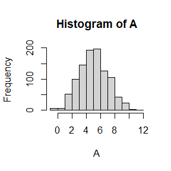

```r
A=rnorm(1000,mean=5,sd=2)
hist(A)
```

### Q2

Here I use a table to show these random numbers’ mean and standard deviation.

```r
T=matrix(0,nrow=2,ncol=2)
colnames(T)=c("mean","sd")
rownames(T)=c("expect","real")
T[1,]=c(5,2)
T[2,]=c(mean(A),sd(A))
knitr::kable(T,digits=c(3,3),align="c")
```

|  | mean | sd |
| --- | --- | --- |
| expect | 5.000 | 2.000 |
| real | 5.019 | 1.997 |

### Q3

Here I show some formulas.
$$\mathbf{Y}_{it}=\beta_0+\mathbf{Z}_i^T\gamma+\beta_1$$
$$\sigma_{it}^2=\alpha_0+\alpha_{1}\frac{1}{n_i}\sum^N_{j=1}a_{ij}e_{i(t-1)}^2+\alpha_2e_{i(t-1)}^2$$
$$\mathbf{W} =
\begin{pmatrix}
\frac{1}{n_1}&&&\\
&\frac{1}{n_2}&&\\
&&\ddots&\\
&&&\frac{1}{n_N}\\
\end{pmatrix}
\begin{pmatrix}
a_{11} & a_{12} & \cdots & a_{1N}\\
a_{21} & a_{22} & \cdots & a_{2N}\\
\vdots & \vdots & \ddots & \vdots\\
a_{N1} & a_{N2} & \cdots & a_{NN},\\
\end{pmatrix}$$

# HOMEWORK 2

## 5.1

Compute a Monte Carlo estimate of
$$\int_0^\frac{\pi}{3}\sin t dt$$
and compare your estimate with the exact value of the integral.

### Solution

Here $\int_0^\frac{\pi}{3}\sin t dt=\int_0^\frac{\pi}{3}\frac{\pi}{3}\sin x \frac{3}{\pi}dx=E[\frac{\pi}{3}\sin U]$, where $U\sim U(0,\frac{\pi}{3})$. So we just need to generate large numbers of $X=\frac{\pi}{3}\sin U$, and calculate their mean, then we will get the value we want.

```r
n=3000#The number of X we choose to generate.
U=runif(n,min=0,max=pi/3)
X=pi/3*sin(U)#get X
E=mean(X)#the mean of X, which is also the value we want
realE=0.5#the real value
rbind(c("right","estimate","difference"),c(realE,E,abs(realE-E)))#compare
```

```
##      [,1]    [,2]                [,3]
## [1,] "right" "estimate"          "difference"
## [2,] "0.5"   "0.498766734504623" "0.00123326549537717"
```

## 5.7

Refer to Exercise 5.6. Use a Monte Carlo simulation to estimate $\theta$ by the antithetic variate approach and by the simple Monte Carlo method. Compute an empirical estimate of the percent reduction in variance using the antithetic variate. Compare the result with the theoretical value from the Exercise 5.6.

### Solution

First we estimate $\theta$ by the simple Monte Carlo method. Similarly as 5.1, $\theta=\int_0^1e^x dx=E[e^U]$, where $U\sim U(0,1)$. So we just need to generate enough numbers of $X=e^U$ and calculate their mean, then we will get the value we want.

```r
set.seed(726)
n=3000#The number of X we choose to generate.
U=runif(n,min=0,max=1)
X=exp(U)#get X
E1=mean(X)#the mean of X, which is also the value we want
realE=exp(1)-1#the real value
rbind(c("right","estimate","difference"),c(realE,E1,abs(realE-E1)))#compare
```

```
##      [,1]               [,2]               [,3]
## [1,] "right"            "estimate"         "difference"
## [2,] "1.71828182845905" "1.70617159085941" "0.0121102375996365"
```

Then we use the antithetic variate approach to estimate $\theta$. Because $\theta=\int_0^1e^x dx=\int_1^0e^{1-x}d(1-x)=\int_0^1e^{1-x}dx$, so $E[e^{1-U}]$ can also used to estimate $\theta$.

```r
n=1500#The number of X we choose to generate.
set.seed(112)
U=runif(n,min=0,max=1)
X1=exp(U)#get X
X2=exp(1-U)
X=(X1+X2)/2
E2=mean(X)#the mean of X, which is also the value we want
realE=exp(1)-1#the real value
rbind(c("right","estimate","difference"),c(realE,E2,abs(realE-E2)))#compare
```

```
##      [,1]               [,2]               [,3]
## [1,] "right"            "estimate"         "difference"
## [2,] "1.71828182845905" "1.71798971568698" "0.000292112772068309"
```

We can see that the differences shows the second method has much less difference than the real value, which seems a better method. Now we compare these two methods and compute the empirical estimate of the percent reduction.

```r
n=3000
V=NULL
for(i in 1:1000){
  Var2=Var1=0
  U=runif(n,0,1)
  X1=exp(U)#simple Monte Carlo method
  X2=(exp(U[1:(n/2)])+exp(1-U[1:(n/2)]))/2#antithetic variate approach
  Var1=var(X1)
  Var2=var(X2)
  V[i]=Var2/Var1
}
mean(V)
```

```
## [1] 0.01615672
```

This result has verified that antithetic variate approach use less samples and get less variance.

## 5.11

If $\hat{\theta_1}$ and $\hat{\theta_2}$ are unbiased estimators of $\theta$, and $\hat{\theta_1}$ and $\hat{\theta_2}$ are antithetic, we derived that $c^{\star}=\frac{1}{2}$ is the optimal constant that minimizes the variance of $\hat{\theta_c}=c\hat{\theta_2}+(1-c)\hat{\theta_2}$. Derive $c^{\star}$ for the general case. That is, if $\hat{\theta_1}$ and $\hat{\theta_2}$ are any two unbiased estimators of $\theta$, find the value $c^\star$ that minimizes the variance of the estimator $\hat{\theta_c}=c\hat{\theta_1}+(1-c)\hat{\theta_2}$ in equation
$$\operatorname{Var}\left(\hat{\theta}_{2}\right)+c^{2} \operatorname{Var}\left(\hat{\theta}_{1}-\hat{\theta}_{2}\right)+2 c \operatorname{Cov}\left(\hat{\theta}_{2}, \hat{\theta}_{1}-\hat{\theta}_{2}\right)$$
.

### Solution

$$\begin{align}
f(c)&=\operatorname{Var}\left(\hat{\theta}_{2}\right)+c^{2} \operatorname{Var}\left(\hat{\theta}_{1}-\hat{\theta}_{2}\right)+2 c \operatorname{Cov}\left(\hat{\theta}_{2}, \hat{\theta}_{1}-\hat{\theta}_{2}\right)\\
&=\operatorname{Var}\left(\hat{\theta}_{1}-\hat{\theta}_{2}\right)(c+\frac{\operatorname{Cov}\left(\hat{\theta}_{2}, \hat{\theta}_{1}-\hat{\theta}_{2}\right)}{\operatorname{Var}\left(\hat{\theta}_{1}-\hat{\theta}_{2}\right)})^2+\operatorname{Var}\left(\hat{\theta}_{2}\right)-\frac{\operatorname{Cov}^2\left(\hat{\theta}_{2}, \hat{\theta}_{1}-\hat{\theta}_{2}\right)}{\operatorname{Var}\left(\hat{\theta}_{1}-\hat{\theta}_{2}\right)}
\end{align}.$$
So when
$$c^{\star}=-\frac{\operatorname{Cov}\left(\hat{\theta}_{2}, \hat{\theta}_{1}-\hat{\theta}_{2}\right)}{\operatorname{Var}\left(\hat{\theta}_{1}-\hat{\theta}_{2}\right)}=\frac{\operatorname{Var}(\hat{\theta}_2)-\operatorname{Cov}(\hat{\theta}_{1},\hat{\theta}_{2})}{\operatorname{Var}(\hat{\theta}_1)+\operatorname{Var}(\hat{\theta}_2)-2\operatorname{Cov}(\hat{\theta}_{1},\hat{\theta}_{2})},$$
we have
$$\begin{align}f_{min}(c)=f(c^{\star})&=\operatorname{Var}\left(\hat{\theta}_{2}\right)-\frac{\operatorname{Cov}^2\left(\hat{\theta}_{2}, \hat{\theta}_{1}-\hat{\theta}_{2}\right)}{\operatorname{Var}\left(\hat{\theta}_{1}-\hat{\theta}_{2}\right)}\\&=\operatorname{Var}(\hat{\theta}_2)(1-\operatorname{Cor}^2(\hat{\theta}_2,\hat{\theta}_1-\hat{\theta}_2))
\end{align}$$
# HOMEWORK 3
## 5.13
Find two importance functions $f_1$ and $f_2$ that are supported on $(1,\infty)$ and are “close” to
$$g(x)=\frac{x^2}{\sqrt{2\pi}}e^{-x^2/2}, x>1$$
Which of your two importance functions should produce the smaller variance in estimating
$$\int_1^{\infty}\frac{x^2}{\sqrt{2\pi}}e^{-x^2/2}dx$$
by importance sampling? Explain.

### Solution

Here $\int_1^{\infty}\frac{x^2}{\sqrt{2\pi}}e^{-x^2/2}dx=\int_1^{\infty}\frac{\sqrt{x}}{2\sqrt{2\pi}}e^{-\frac{x}{2}}dx$. We choose $f_1=e^{-\frac{x}{2}}$ and $f_2=\frac{1}{x^2}$.

```r
n=3000#numbers of variables
g=function(x){
  x^0.5*exp(-x/2)/2/(2*pi)^0.5*(x>1)
}
#f1=e^(-x/2)
##cdf F1=1-e^(-(x-1)/2)
u=runif(n)
x=-2*log(1-u)+1
fg=g(x)/exp(-x/2)
E1=mean(fg)
SD1=sd(fg)
#f2=1/x^2
##cdf F2=1-1/x
u=runif(n)
x=1/(1-u)
fg=g(x)*x^2
E2=mean(fg)
SD2=sd(fg)
#results
cbind("E"=c(E1,E2),"SD"=c(SD1,SD2))
```

```
##              E        SD
## [1,] 0.3315404 0.1018910
## [2,] 0.4044214 0.2693487
```

The first function $f_1=e^{-\frac{x}{2}}$ produces smaller variance. We can find the reason from the following picture.

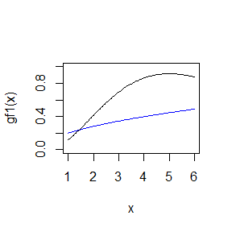

The blue line represents $g(x)/f_1(x)$, and the black line represents $g(x)/f_2(x)$. It’s clear that the blue line is mach smaller than the black line in most of the part. So $Var(g(x)/f_1(x))<Var(g(x)/f_2(x))$.

## 5.15

Obtain the stratified importance sampling estimate in Example 5.13 and compare it with the result of Example 5.10.

### Sulution

Our goal is to estimate $\int_0^1\frac{e^{-x}}{1+x^2}dx$.  
In Example 5.10, the best result was obtained with importance function $f_3=e^{-x}/(1-e^{-1})$.  
In Example 5.13, we divide the interval(0,1) into five subintervals. Here is how it goes.

```r
n=3000
k=5
m=n/k#replicates per stratum
N=100#number of times to repeat the estimation
g=function(x){
  exp(-x)/(1+x^2)*(x>0)*(x<1)
}
E1=NULL
E2=NULL
for(i in 1:N){
  U=runif(n)
  x=g(U)
  E1[i]=mean(x)
  E=NULL
  for(j in 1:k){
    u=runif(m,(j-1)/k,j/k)
    x=g(u)
    E[j]=mean(x)
  }
  E2[i]=mean(E)
}
cbind("mean"=c(mean(E1),mean(E2)),"sd"=c(sd(E1),sd(E2)))
```

```
##           mean           sd
## [1,] 0.5246601 0.0045523655
## [2,] 0.5247083 0.0009588614
```

So the sd is much smaller than we get in Example 5.10.

## 6.4

Suppose that $X_1,\dots,X_n$ are a random sample from a lognormal distribution with unknown parameters. Construct a 95% confidence interval for the parameter $\mu$. Use a Monte Carlo method to obtain an empirical estimate of the confidence level.

### Solution

We know that if X has the distribution of lognormal, then Y=ln(X) has normal distribution.

```r
miu=2
s=1
n=10
alpha=0.05
X=exp(rnorm(n,miu,s))
miu_hat=mean(log(X))
S_hat=sum((log(X)-miu_hat)^2)/(n-1)
CI=c(miu_hat-S_hat*qt(1-alpha/2,n-1)/n^0.5,miu_hat+S_hat*qt(1-alpha/2,n-1)/n^0.5)
c((CI[1]),(CI[2]))#95%CI
```

```
## [1] 1.973273 2.925902
```

Next we repeat the process to see its real confidence level.

```r
m=3000#repeat times
CI=matrix(0,nrow=m,ncol=2)
q=0
for(i in 1:m){
  X=exp(rnorm(n,miu,s))
  miu_hat=mean(log(X))
  S_hat=(sum((log(X)-miu_hat)^2)/(n-1))^0.5
  CI[i,]=c(miu_hat-S_hat*qt(1-alpha/2,n-1)/n^0.5,miu_hat+S_hat*qt(1-alpha/2,n-1)/n^0.5)
  if(CI[i,1]<=miu&&CI[i,2]>=miu)q=q+1
}
q/m
```

```
## [1] 0.9516667
```

## 6.5

Suppose a 95% symmetric t-interval is applied to estimate a mean, but the sample data are non-normal. Then the probability that the confidence interval covers the mean is not necessarily equal to 0.95. Use a Monte Carlo experiment to estimate the coverage probability of the t-interval for random samples of $\mathcal{X}^2(2)$ data with sample size $n=20$. Compare your t-interval results with the simulation results in Example 6.4.(The t-interval should be more robust to departures from normality than the interval for variance.)

### Solution

```r
n=20
alpha=0.05
m=1000
q=p=0
U1=matrix(0,nrow=m,ncol=2)
U2=matrix(0,nrow=m,ncol=2)
for(i in 1:m){
  X1=rchisq(n,df=2)
  S=(sum((X1-mean(X1))^2)/(n-1))^0.5
  U1[i,]=c(mean(X1)-S*qt(1-alpha/2,n-1)/n^0.5,mean(X1)+S*qt(1-alpha/2,n-1)/n^0.5)
  U2[i,]=c(mean(X1)-S*qnorm(1-alpha/2)/n^0.5,mean(X1)+S*qnorm(1-alpha/2)/n^0.5)
  if(U1[i,1]<=2&&U1[i,2]>=2)q=q+1
  if(U2[i,1]<=2&&U2[i,2]>=2)p=p+1
}
q/m#t-interval
```

```
## [1] 0.927
```

```r
p/m#interval for variance
```

```
## [1] 0.911
```

# HOMEWORK 4

## 6.7

Estimate the power of the skewness test of normality against symmetric $Beta(\alpha,\alpha)$ distributions and comment on the results. Are the results different for heavy-tailed symmetric alternatives such as $t(v)$?

### Solution

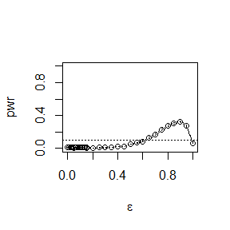

```r
sk <- function(x) {
#computes the sample skewness coeff.
xbar <- mean(x)
m3 <- mean((x - xbar)^3)
m2 <- mean((x - xbar)^2)
return( m3 / m2^1.5 )
}
alpha <- .1
n <- 30
m <- 2500
epsilon <- c(seq(0, .15, .01), seq(.15, 1, .05))
N <- length(epsilon)
pwr <- numeric(N)
#critical value for the skewness test
cv <- qnorm(1-alpha/2, 0, sqrt(6*(n-2) / ((n+1)*(n+3))))
for (j in 1:N) { #for each epsilon
  e <- epsilon[j]
  sktests <- numeric(m)
  for (i in 1:m) { #for each replicate
    a <- sample(c(1, 10), replace = TRUE,
                    size = n, prob = c(1-e, e))
    x <- rbeta(n, a, a)
    sktests[i] <- as.integer(abs(sk(x)) >= cv)
  }
  pwr[j] <- mean(sktests)
}
#plot power vs epsilon
plot(epsilon, pwr, type = "b",
     xlab = bquote(epsilon), ylim = c(0,1))
abline(h = .1, lty = 3)
se <- sqrt(pwr * (1-pwr) / m) #add standard errors
lines(epsilon, pwr+se, lty = 3)
lines(epsilon, pwr-se, lty = 3)
```

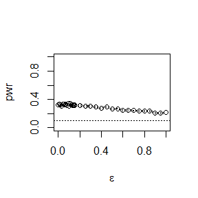

```r
alpha <- .1
n <- 30
m <- 2500
epsilon <- c(seq(0, .15, .01), seq(.15, 1, .05))
N <- length(epsilon)
pwr <- numeric(N)
#critical value for the skewness test
cv <- qnorm(1-alpha/2, 0, sqrt(6*(n-2) / ((n+1)*(n+3))))
for (j in 1:N) { #for each epsilon
  e <- epsilon[j]
  sktests <- numeric(m)
  for (i in 1:m) { #for each replicate
    v <- sample(c(5, 10), replace = TRUE,
                    size = n, prob = c(1-e, e))
    x <- rt(n, v)
    sktests[i] <- as.integer(abs(sk(x)) >= cv)
  }
  pwr[j] <- mean(sktests)
}
#plot power vs epsilon
plot(epsilon, pwr, type = "b",
     xlab = bquote(epsilon), ylim = c(0,1))
abline(h = .1, lty = 3)
se <- sqrt(pwr * (1-pwr) / m) #add standard errors
lines(epsilon, pwr+se, lty = 3)
lines(epsilon, pwr-se, lty = 3)
```

The result is very different from what we get in Beta distribution.

## 6.8

Refer to Example 6.16. Repeat the simulation, but also compute the F test of equal variance, at significance level $\hat{\alpha}=0.055$. Compare the power of the Count Five test and F test for small, medium, and large sample sizes.(Recall that the F test is not applicable for non-normal distributions.)  
### Solution

```r
count5test <- function(x, y) {
  X <- x - mean(x)
  Y <- y - mean(y)
  outx <- sum(X > max(Y)) + sum(X < min(Y))
  outy <- sum(Y > max(X)) + sum(Y < min(X))
  # return 1 (reject) or 0 (do not reject H0)
  return(as.integer(max(c(outx, outy)) > 5))
}
Ftest=function(x,y,n){
  X <- x - mean(x)
  Y <- y - mean(y)
  S1=sum(X^2)/(length(x)-1)
  S2=sum(Y^2)/(length(y)-1)
  return(as.integer(S1/S2>=qf(1-0.055,n-1,n-1)))
}
sigma1 <- 1
sigma2 <- 1.5
m=10000
n=c(20,50,200)
power=matrix(0,nrow=3,ncol=2)
for(i in 1:3){
  power[i,] <- rowMeans(replicate(m, expr={
    x <- rnorm(n[i], 0, sigma1)
    y <- rnorm(n[i], 0, sigma2)
    c(count5test(x, y),Ftest(x,y,n[i]))
  }))
}
power
```

```
##        [,1]  [,2]
## [1,] 0.3092 8e-04
## [2,] 0.6608 0e+00
## [3,] 0.9505 0e+00
```

## 6.C

Repeat Examples 6.8 and 6.10 for Mardia’s multivariate skewness test. Mardia proposed tests of multivariate normality based on multivariate generalizations of skewness and kurtosis. If X and Y are iid, the multivariate population skewness $\beta_{1,d}$ is defined by Mardia as
$$\beta_{1, d}=E\left[(X-\mu)^{T} \Sigma^{-1}(Y-\mu)\right]^{3}.$$
Under normality, $\beta_{1,d}=0$. The multivariate skeweness statistic is
$$b_{1, d}=\frac{1}{n^{2}} \sum_{i, j=1}^{n}\left(\left(X_{i}-\bar{X}\right)^{T} \widehat{\Sigma}^{-1}\left(X_{j}-\bar{X}\right)\right)^{3}$$
Where $\widehat{\Sigma}$ is the maximum likelihood estimator of covariance. Large values of $b_{1,d}$ are significant. The asymptotic distribution of $nb_{1,d}/6$ is chisquared with d(d + 1)(d + 2)/6 degrees of freedom.

### Solution

#### Example 6.8

Here I set d=3.

```r
n=c(5,10,50)
cv=qchisq(0.975,3*4*5/6)
sk <- function(x,n) {
  #computes the sample skewness coeff.
  xbar=c(mean(x[,1]),mean(x[,2]),mean(x[,3]))
  E=solve(cov(x,x))
  m=0
  y=x-xbar
  for(l1 in 1:(n-1)){
    for(l2 in (l1+1):n){
      m=m+2*(t(y[l1,])%*%E%*%y[l2,])^3
    }
    m=m+(t(y[l1,])%*%E%*%y[l1,])^3
  }
  m=m+(t(y[n,])%*%E%*%y[n,])^3
  return(m/n^2)
}
p.reject <- numeric(length(n))#to store sim. results
m <- 10000 #num. repl. each sim.
for (i in 1:length(n)) {
  sktests <- numeric(m) #test decisions
  for (j in 1:m) {
    x <- cbind(rnorm(n[i]),rnorm(n[i]),rnorm(n[i]))
    #test decision is 1 (reject) or 0
    sktests[j] <- as.integer(abs(n[i]*sk(x,n[i])/6) >= cv )
  }
  p.reject[i] <- mean(sktests) #proportion rejected  }
}
p.reject
```

```
## [1] 0.5688 0.2669 0.2010
```

Compared with the result in Example 6.8, we can find that the probability of type I error is much bigger than before.

#### Example 6.10

Here d=1.

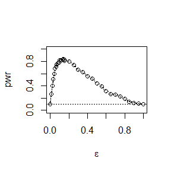

```r
sk <- function(x) {
#computes the sample skewness coeff.
xbar <- mean(x)
m3 <- mean((x - xbar)^3)
m2 <- mean((x - xbar)^2)
return( m3 / m2^1.5 )
}
alpha <- .1
n <- 30
m <- 2500
epsilon <- c(seq(0, .15, .01), seq(.15, 1, .05))
N <- length(epsilon)
pwr <- numeric(N)
#critical value for the skewness test
cv <- qnorm(1-alpha/2, 0, sqrt(6*(n-2) / ((n+1)*(n+3))))
for (j in 1:N) { #for each epsilon
  e <- epsilon[j]
  sktests <- numeric(m)
  for (i in 1:m) { #for each replicate
   sigma <- sample(c(1, 10), replace =TRUE,size = n, prob = c(1-e, e))
   x <- rnorm(n, 0, sigma)
   sktests[i] <- as.integer(abs(sk(x)) >= cv)
  }
  pwr[j] <- mean(sktests)
}
#plot power vs epsilon
plot(epsilon, pwr, type = "b",
     xlab = bquote(epsilon), ylim = c(0,1))
abline(h = .1, lty = 3)
se <- sqrt(pwr * (1-pwr) / m) #add standard errors
lines(epsilon, pwr+se, lty = 3)
lines(epsilon, pwr-se, lty = 3)
```

## Discussion

$$H_0:p1=p2, H_A:p1\ne p2$$
We should use z-test.
For methods 1, suppose the probability to reject the null hypothesis is $p_1$, and for methods 2, suppose the probability to reject the null hypothesis is $p_2$. If we repeat the experiments for many times, the results we get are actually obey binomial distribution.

```r
p1=0.676
p2=0.651
pc=(p1+p2)/2
n=10000
1-pnorm(p1-p2,0,(pc*(1-pc)*(2/n))^0.5)
```

```
## [1] 9.156844e-05
```

So we can say the powers are different at 0.05 level.

# HOMEWORK 5

## 7.1

Compute a jackknife estimate of the bias and the standard error of the correlation statistic in Example 7.2  
In example 7.2, the data used are from the bootstrap package, so I load bottstrap first.

```r
library(bootstrap)
n=length(law[,1])#the length of data
theta.hat=cor(law$LSAT,law$GPA)#original data correlation
theta.jack=numeric(n)#set to store statistics from jackknife
for(i in 1:n){
  theta.jack[i] <- cor(law$LSAT[-i],law$GPA[-i])#leave the ith data out
}
bias.jack <- (n-1)*(mean(theta.jack)-theta.hat)#compute the bias
se.jack <- sqrt((n-1)*mean((theta.jack-theta.hat)^2))#compute the standard error
round(c(original=theta.hat,bias.jack=bias.jack,
        se.jack=se.jack),3)#to show results
```

```
##  original bias.jack   se.jack
##     0.776    -0.006     0.143
```

## 7.5

Refer to Excercise 7.4. Compute 95% bootstrap confidence intercals for the mean time between failures $1/\lambda$ by the standard normal, basic, percentile, and BCa methods. Compare the intervals and explain why they may differ.

```r
library(boot)
m=1e3
ci.norm<-ci.basic<-ci.perc<-ci.bca<-matrix(NA,m,2)
boot.mean <- function(x,i){
  mean(x[i])
}
dat=c(3,5,7,18,43,85,91,98,100,130,230,487)
for(i in 1:m){
  de <- boot(dat,statistic=boot.mean, R = 1000)
  ci <- boot.ci(de,type=c("norm","basic","perc","bca"))
  ci.norm[i,]<-ci$norm[2:3]
  ci.basic[i,]<-ci$basic[4:5]
  ci.perc[i,]<-ci$percent[4:5]
  ci.bca[i,]<-ci$bca[4:5]
}
cat('norm =',c(mean(ci.norm[,1]),mean(ci.norm[,2])),
    'basic =',c(mean(ci.basic[,1]),mean(ci.basic[,2])),
    'perc =',c(mean(ci.perc[,1]),mean(ci.perc[,2])),
    'BCa =',c(mean(ci.bca[,1]),mean(ci.bca[,2]))
)
```

```
## norm = 34.31574 181.7975 basic = 24.65124 169.4786 perc = 46.68811 191.5154 BCa = 56.8603 227.9891
```

## 7.8

Refer to Exercise 7.7, Obtain the jackknife estimate of bias and standard error of $\hat{\theta}$.

```r
library(bootstrap)
n=length(scor[,1])
lambda_hat=eigen(cov(scor))$values
theta_hat=lambda_hat[1]/sum(lambda_hat)
theta_jack=rep(0,n)
for (i in 1:n) {
 lambda=eigen(cov(scor[-i,]))$values
 theta_jack[i]=lambda[1]/sum(lambda)
}
bias.jack <- (n-1)*(mean(theta.jack)-theta.hat)#compute the bias
se.jack <- sqrt((n-1)*mean((theta.jack-theta.hat)^2))#compute the standard error
round(c(original=theta.hat,bias.jack=bias.jack,
        se.jack=se.jack),3)#to show results
```

[output not shown]

## 7.11

In example 7.18, leave-one-out(n-fold) cross validation was used to select the best fitting model. Use leave-two-out cross validation to compare the models.

```r
library(DAAG)
attach(ironslag)
n <- length(magnetic) #in DAAG ironslag
e1 <- e2 <- e3 <- e4 <- numeric(n*(n-1)/2)
p=0
for (i in 1:(n-1))
  for (j in (i+1):n) {
    p=p+1
    y=magnetic[-c(i,j)]
    x=chemical[-c(i,j)]

    P1=lm(y~x)
    y1_1=chemical[i]*P1$coef[2] + P1$coef[1]
    y1_2=chemical[j]*P1$coef[2] + P1$coef[1]
    e1[p]=(magnetic[i]-y1_1)^2+(magnetic[j]-y1_2)^2

    P2=lm(y~x+I(x^2))
    y2_1=P2$coef[1] + P2$coef[2] * chemical[i] + P2$coef[3] * chemical[i]^2
    y2_2=P2$coef[1] + P2$coef[2] * chemical[j] + P2$coef[3] * chemical[j]^2
    e2[p]=(magnetic[i]-y2_1)^2+(magnetic[j]-y2_2)^2

    P3=lm(log(y)~x)
    y3_1=exp(P3$coef[1] + P3$coef[2] * chemical[i])
    y3_2=exp(P3$coef[1] + P3$coef[2] * chemical[j])
    e3[p]=(magnetic[i]-y3_1)^2+(magnetic[j]-y3_2)^2

    P4=lm(log(y)~log(x))
    y4_1=exp(P4$coef[1] + P4$coef[2] * log(chemical[i]))
    y4_2=exp(P4$coef[1] + P4$coef[2] * log(chemical[j]))
    e4[p]=(magnetic[i]-y4_1)^2+(magnetic[j]-y4_2)^2
  }
e = c(mean(e1)/2,mean(e2)/2,mean(e3)/2,mean(e4)/2)
matrix(e, nrow=1,dimnames=list("prediction error", c("Linear","Quadratic"," Exponential","Log-Log")))
```

```
##                    Linear Quadratic  Exponential  Log-Log
## prediction error 19.57227  17.87018     18.45491 20.46718
```

```r
detach(ironslag)
```

The prediction error is a little bit lagerer than leave-one-out cross validation.  
# HOMEWORK 6  
## 8.3  
The Count 5 test for equal variances in Section 6.4 is based on the maximum number of extreme points. Example 6.15 shows that the Count 5 criterion is not applicable for unequal sample sizes. Implement a permutation test for equal variance based on the maximum number of extreme points that applies when sample sizes are not necessarily equal.

```r
count5=function(x1,x2){
  x1=x1-mean(x1)
  x2=x2-mean(x2)
  out1 <- sum(x1 > max(x2)) + sum(x1 < min(x2))
  out2 <- sum(x2 > max(x1)) + sum(x2 < min(x1))
  return(max(c(out1, out2)))
}
count5_per=function(z){
  n=length(z)
  x=z[1:(n/2)]
  y=z[-(1:(n/2))]
  a=count5(x,y)
  return(a)
}
per=function(z,R){
  n=length(z)
  result=numeric(R)
  for (i in 1:R){
    q=sample(1:n,n,replace=FALSE)
    result[i]=count5_per(z[q])
  }
  return(sum(result>5)/R)
}
n1=20
n2=40
mu1=mu2=0
s1=s2=2
R=1e3
test1=test2=numeric(R)
#compare
for(i in 1:R){
  x=rnorm(n1,mu1,s1)
  y=rnorm(n2,mu2,s2)
  test1[i]=(count5(x,y)>5)
  z=c(x,y)
  test2[i]=per(z,500)
}
c(mean(test1),mean(test2<0.05))
```

```
## [1] 0.218 0.134
```

### Design experiments for evaluating the performance of the NN, energy, and ball methods in various situations(Note: The parameters should be chosen such that the powers are distinguishable (say, range from 0.3 to 0.8).

#### Unequal variances and equal expectations

#### Unequal variances and unequal expectations

#### Non-normal distributions: t distribution with 1 df (heavy-tailed distribution), bimodel distribution (mixture of two normal distributions)

#### Unbalanced samples (say, 1 case versus 10 controls)

```r
library(RANN)
library(boot)
library(Ball)
library(energy)
library(MASS)
#NN-methods
Tn <- function(z, ix, sizes,k) {
  n1 <- sizes[1]; n2 <- sizes[2]; n <- n1 + n2
  if(is.vector(z)) z <- data.frame(z,0);
  z <- z[ix, ];
  NN <- nn2(data=z, k=k+1)
  block1 <- NN$nn.idx[1:n1,-1]
  block2 <- NN$nn.idx[(n1+1):n,-1]
  i1 <- sum(block1 < n1 + .5); i2 <- sum(block2 > n1+.5)
  (i1 + i2) / (k * n)
}
NN=function(z,sizes,k){
  boot.obj <- boot(data=z,statistic=Tn,R=R, sim = "permutation", sizes = sizes,k=k)
  ts <- c(boot.obj$t0,boot.obj$t)
  p.value <- mean(ts>=ts[1])
  return(c(statistic=ts[1],p.value=p.value))
}
#energy
# eqdist.etest in package energy
#ball
# bd.test in package Ball
#settings
n1=n2=20
n=n1+n2
N=c(n1,n2)
k=3
R=500
m=100
alpha=0.05
#compare
com=function(mu1,mu2,s1,s2,alpha){
  p.values=matrix(NA,m,3)
  for(i in 1:m){
    data1=mvrnorm(n1,mu1,sigma1)
    data2=mvrnorm(n2,mu2,sigma2)
    data=rbind(data1,data2)
    p.values[i,1]=NN(data,N,k)[2]
    p.values[i,2]=eqdist.etest(data,sizes=N,R=R)$p.value
    p.values[i,3]=bd.test(x=data1,y=data2,num.permutations=R,seed=i*2846)$p.value
  }
  p=colMeans(p.values<alpha)
  return(p)
}

#Unequal variances and equal expectations
mu1=mu2=c(0,0,0)
sigma1 <- matrix(c(1,0,0,0,1,0,0,0,1),nrow=3,ncol=3)
sigma2 <- matrix(c(2,0,0,0,3,0,0,0,4),nrow=3,ncol=3)
result1=com(mu1,mu2,s1,s2,alpha)

#Unequal variances and unequal expectations
mu1 <- c(0,0,0)
sigma1 <- matrix(c(1,0,0,0,1,0,0,0,1),nrow=3,ncol=3)
mu2 <- c(0.5,-0.5,1)
sigma2 <- matrix(c(2,0,0,0,2,0,0,0,2),nrow=3,ncol=3)
result2=com(mu1,mu2,s1,s2,alpha)

#Non-normal distributions
#t distribution with 1 df (heavy-tailed distribution)
p.values <- matrix(NA,m,3)
for(i in 1:m){
  data1=rt(n1,1,2)
  data2=rt(n2,2,5)
  data=c(data1,data2)
  p.values[i,1]=NN(data,N,k)[2]
  p.values[i,2]=eqdist.etest(data,sizes=N,R=R)$p.value
  p.values[i,3]=bd.test(x=data1,y=data2,num.permutations=R,seed=i*2846)$p.value
}
result3=colMeans(p.values<alpha)
#bimodel distribution (mixture of two normal distributions)
bimodel<-function(n,mu1,mu2,sd1,sd2){
  index=sample(1:2,n,replace=TRUE)
  x=numeric(n)
  index1<-which(index==1)
  x[index1]<-rnorm(length(index1),mu1,sd1)
  index2<-which(index==2)
  x[index2]<-rnorm(length(index2),mu2,sd2)
  return(x)
}
p.values <- matrix(NA,m,3)
for(i in 1:m){
  data1=bimodel(n1,0,0,1,2)
  data2=bimodel(n2,2,2,2,4)
  data=c(data1,data2)
  p.values[i,1]=NN(data,N,k)[2]
  p.values[i,2]=eqdist.etest(data,sizes=N,R=R)$p.value
  p.values[i,3]=bd.test(x=data1,y=data2,num.permutations=R,seed=i*2846)$p.value
}
result4=colMeans(p.values<alpha)

#Unbalanced samples (say, 1 case versus 10 controls)
n2=10*n1
n=n1+n2
N=c(n1,n2)
result5=com(mu1,mu2,s1,s2,alpha)
rbind(result1,result2,result3,result4,result5)
```

```
##         [,1] [,2] [,3]
## result1 0.33 0.35 0.89
## result2 0.53 0.80 0.91
## result3 0.65 0.56 0.88
## result4 0.54 0.96 0.95
## result5 0.24 0.97 1.00
```

# HOMEWORK 7

## 9.4

Implement a random walk Metropolis sampler for generating the standard Laplace distribution (see Exercise 3.2). For the increment, simulate from a normal distribution. Compare the chains generated when different variances are used for the proposal distribution. Also, compute the acceptance rates of each chain.

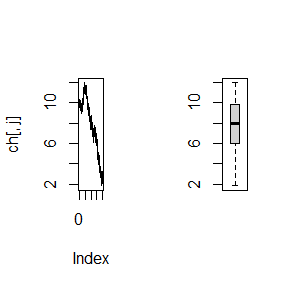

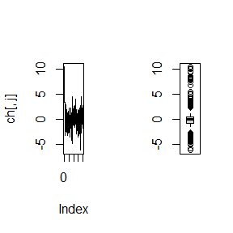

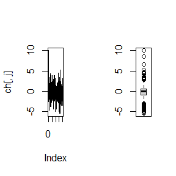

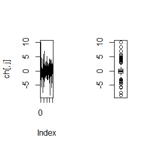

```r
#standard Laplace dendity distribution
f=function(x) 0.5*exp(-abs(x))
#random walk
Metro=function(sd,x0,N){
  x=numeric(N)
  x[1]=x0
  u=runif(N)
  p=0
  for (i in 2:N) {
    y=rnorm(1,x[i-1],sd)
    if(u[i]<=(f(y)/f(x[i-1]))) x[i]=y
    else {
      x[i]=x[i-1]
      p=p+1
    }
  }
  return(c(x,p))
}
#compare the chains generated with different variances
N=2000
sd=c(0.1,1,5,10)
x0=10
ch1=Metro(sd[1],x0,N)
ch2=Metro(sd[2],x0,N)
ch3=Metro(sd[3],x0,N)
ch4=Metro(sd[4],x0,N)
#Compare the chains
par(mfrow=c(1,2))
ch=cbind(ch1[1:N],ch2[1:N],ch3[1:N],ch4[1:N])
for (j in 1:4) {
  plot(ch[,j], type="l")
  boxplot(ch[,j])
}
```

```r
#acceptance rates
R=c(ch1[N+1],ch2[N+1],ch3[N+1],ch4[N+1])
Acc=(N-R)/N
Acc
```

```
## [1] 0.9615 0.6770 0.2810 0.1545
```

As the variance is increasing, the acceptance rate is decreasing.

## 9.4+

For Exercise 9.4, use the Gelman-Rubin method to monitor convergence of the chain, and run the chain until it converges approximately to the target distribution according to $\hat{R}<1.2$.

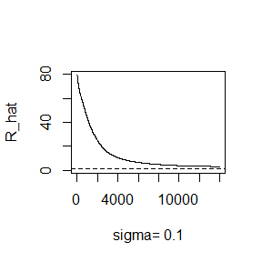

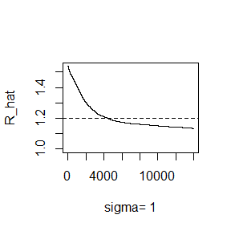

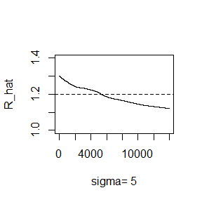

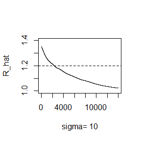

```r
Gelman.Rubin <- function(psi) {
  # psi[i,j] is the statistic psi(X[i,1:j])
  # for chain in i-th row of X
  psi <- as.matrix(psi)
  n <- ncol(psi)
  k <- nrow(psi)
  psi.means <- rowMeans(psi) #row means
  B <- n * var(psi.means) #between variance est.
  psi.w <- apply(psi, 1, "var") #within variances
  W <- mean(psi.w) #within est.
  v.hat <- W*(n-1)/n + (B/n) #upper variance est.
  r.hat <- v.hat / W #G-R statistic
  return(r.hat)
}

k=4 #number of chains to generate
b=1000 #burn-in length
N=15000
#choose overdispersed initial values
x0 <- c(-10, -5, 5, 10)
sd=c(0.1,1,5,10)
par(mfrow=c(1,1))
for(z in 1:4){
 X=matrix(nrow=k,ncol=N)
 for (i in 1:k){
   X[i,]=Metro(sd[z],x0[i],N)[1:N]
 }
 psi=t(apply(X, 1, cumsum))
 for (i in 1:nrow(psi))
   psi[i,]=psi[i,]/(1:ncol(psi))
 rhat=rep(0, N)
 for (j in (b+1):N)
   rhat[j]=Gelman.Rubin(psi[,1:j])
 plot(rhat[(b+1):N], type="l", xlab=paste("sigma=",sd[z]), ylab="R_hat", ylim=c(1,max(max(rhat[(b+1):N]),1.4)))
 abline(h=1.2,lty=2)
}
```

## 11.4

Find the intersection points $A(k)$ in $(0,\sqrt{k})$ of the curves
$$S_{k-1}(a)=P(t(k-1)>\sqrt{\frac{a^2(k-1)}{k-a^2}})$$
and
$$S_{k}(a)=P(t(k)>\sqrt{\frac{a^2k}{k+1-a^2}}),$$
for $k=4:25,100,500,1000$, where $t(k)$ is a Student t random variable with k degrees of freedom.

```r
k=c(4:25,100,500,1000)
S=function(a,k){
  z=sqrt(a^2*k/(k+1-a^2))
  p=pt(z,df=k,lower.tail=FALSE)
  return(p)
}
f=function(a,k){
  S(a,k)-S(a,k-1)
}
solve = function(k){
  out=uniroot(function(a){S(a,k)-S(a,k-1)},lower=1,upper=2)
  return(out$root)
}
n=length(k)
A_k=matrix(0,ncol=n,nrow=2)
for (i in 1:n){
  A_k[2,i]=solve(k[i])
}
A_k[1,]=k
A_k
```

```
##          [,1]     [,2]     [,3]    [,4]     [,5]     [,6]     [,7]      [,8]
## [1,] 4.000000 5.000000 6.000000 7.00000 8.000000 9.000000 10.00000 11.000000
## [2,] 1.492103 1.533556 1.562744 1.58443 1.601185 1.614521  1.62539  1.634419
##           [,9]     [,10]    [,11]     [,12]     [,13]     [,14]     [,15]
## [1,] 12.000000 13.000000 14.00000 15.000000 16.000000 17.000000 18.000000
## [2,]  1.642038  1.648554  1.65419  1.659114  1.663452  1.667303  1.670745
##         [,16]     [,17]     [,18]     [,19]    [,20]     [,21]     [,22]
## [1,] 19.00000 20.000000 21.000000 22.000000 23.00000 24.000000 25.000000
## [2,]  1.67384  1.676637  1.679178  1.681496  1.68362  1.685572  1.687373
##           [,23]      [,24]       [,25]
## [1,] 100.000000 500.000000 1000.000000
## [2,]   1.720608   1.729755    1.730907
```

# HOMEWORK 8

## A-B-O blood type problem

Let the three alleles be A,B,and O.
$$\begin{array}{l|l|l|l|l|l|l|l}
\hline \text { Genotype } & \text { AA } & \text { BB } & \text { OO } & \text { AO } & \text { BO } & \text { AB } & \text { Sum } \\
\hline \text { Frequency } & \mathrm{p}^{\wedge} 2 & \mathrm{q}^{\wedge} 2 & \mathrm{r}^{\wedge} 2 & 2 \mathrm{pr} & 2 \mathrm{qr} & 2 \mathrm{pq} & 1 \\
\hline \text { Count } & \mathrm{nAA} & \mathrm{nBB} & \mathrm{nOO} & \mathrm{nAO} & \mathrm{nBO} & \mathrm{nAB} & \mathrm{n} \\
\hline
\end{array}$$
Obseved data: $n_A.=n_{AA}+n_{AO}=444$(A-type),
$n_B.=n_{BB}+n_{BO}=132$(B-type),
$n_{OO}=361$(O-type),
$n_{AB}=63$(AB-type).
1.Use EM algorithm to solve MLE of p and q (consider missing data $n_{AA}$ and $n_{BB}$).
2.Record the values of p and q that maximize the conditional likelihood in each EM steps, calculate the corresponding log-maximum likelihood values (for observed data), are they increasing?

```r
library(nloptr)
eval_f0 = function(x,x1,nA=444,nB=132,nOO=361,nAB=63) {
  r1=1-sum(x1)
  nAA=nA*x1[1]^2/(x1[1]^2+2*x1[1]*r1)
  nBB=nB*x1[2]^2/(x1[2]^2+2*x1[2]*r1)
  r=1-sum(x)
  return(-2*nAA*log(x[1])-2*nBB*log(x[2])-2*nOO*log(r)-(nA-nAA)*log(2*x[1]*r)-(nB-nBB)*log(2*x[2]*r)-nAB*log(2*x[1]*x[2]))
}
eval_g0 = function(x,x1,nA=444,nB=132,nOO=361,nAB=63){
  return(sum(x)-0.99999)
}
mle=NULL
r=matrix(c(0.5,0.5),1,2)#the beginning value of p and q
j=1
while(sum(abs(r[j,]-r[j-1,]))>1e-7||j<=1){
  res = nloptr( x0=c(0.2,0.25),eval_f=eval_f0,lb = c(0,0),ub = c(1,1),eval_g_ineq = eval_g0,
                opts=list("algorithm"="NLOPT_LN_COBYLA","xtol_rel"=1.0e-7),x1=r[j,],nA=444,nB=132,nOO=361,nAB=63)
  j=j+1
  r=rbind(r,res$solution)
  mle=c(mle,eval_f0(x=r[j,],x1=r[j-1,]))
}
#results
n=length(r[,1])
p=r[n,1]
q=r[n,2]
list("results"=c(p,q),"mle"=-mle,"each step"=r)
```

```
## $results
## [1] 0.2976407 0.1027063
##
## $mle
##  [1] -1991.102 -1573.554 -1455.089 -1432.665 -1428.611 -1427.878 -1427.745
##  [8] -1427.721 -1427.717 -1427.716 -1427.716
##
## $`each step`
##            [,1]      [,2]
##  [1,] 0.5000000 0.5000000
##  [2,] 0.4754999 0.1635000
##  [3,] 0.3416511 0.1096863
##  [4,] 0.3062087 0.1034977
##  [5,] 0.2992214 0.1028197
##  [6,] 0.2979287 0.1027251
##  [7,] 0.2976930 0.1027096
##  [8,] 0.2976501 0.1027069
##  [9,] 0.2976424 0.1027064
## [10,] 0.2976410 0.1027063
## [11,] 0.2976407 0.1027063
## [12,] 0.2976407 0.1027063
```

We can see from the values of mle in the second list that they are increasing.

## Excersice 11.1.2 3

Use both for loops and lapply() to fit linear models to the mtcars using the formulas stored in this list: formulas <- list( mpg ~ disp, mpg ~ I(1 / disp), mpg ~ disp + wt, mpg ~ I(1 / disp) + wt )

```r
formulas = list(
  mpg ~ disp,
  mpg ~ I(1 / disp),
  mpg ~ disp + wt,
  mpg ~ I(1 / disp) + wt
)
attach(mtcars)
#loops
r=list()
for (i in length(formulas)){
  r=c(r,list(lm(formulas[[i]],data=mtcars)))
}
r
```

```
## [[1]]
##
## Call:
## lm(formula = formulas[[i]], data = mtcars)
##
## Coefficients:
## (Intercept)    I(1/disp)           wt
##      19.024     1142.560       -1.798
```

```r
#lapply
l=lapply(formulas,function(x) lm(formula=x, data=mtcars))
l
```

```
## [[1]]
##
## Call:
## lm(formula = x, data = mtcars)
##
## Coefficients:
## (Intercept)         disp
##    29.59985     -0.04122
##
##
## [[2]]
##
## Call:
## lm(formula = x, data = mtcars)
##
## Coefficients:
## (Intercept)    I(1/disp)
##       10.75      1557.67
##
##
## [[3]]
##
## Call:
## lm(formula = x, data = mtcars)
##
## Coefficients:
## (Intercept)         disp           wt
##    34.96055     -0.01772     -3.35083
##
##
## [[4]]
##
## Call:
## lm(formula = x, data = mtcars)
##
## Coefficients:
## (Intercept)    I(1/disp)           wt
##      19.024     1142.560       -1.798
```

## Excersice 11.2.5 3

The following code simulates the performance of a t-test for non-normal data. Use sapply() and an anonymous function to extract the p-value from every trial. trials <- replicate( 100, t.test(rpois(10, 10), rpois(7, 10)), simplify = FALSE )

```r
trials = replicate(
  100,
  t.test(rpois(10, 10), rpois(7, 10)),
  simplify = FALSE
)
sapply(trials,function(x) x[["p.value"]])
```

```
##   [1] 0.153215606 0.435605222 0.958127450 0.630591608 0.003168570 0.149734745
##   [7] 0.099844666 0.297556646 0.376794868 0.081474709 0.730146321 0.251799932
##  [13] 0.957713894 0.082918436 0.778632438 0.775213597 0.310840787 0.945649375
##  [19] 0.328069804 0.519367925 0.146913224 0.558597285 0.089019946 0.569883457
##  [25] 0.593103157 0.940309240 0.323325168 0.295644480 0.430986583 0.125237195
##  [31] 0.182164684 0.457680176 0.910820198 0.467984070 0.271697753 0.189492305
##  [37] 0.059395211 0.613293487 0.465519954 0.786871647 0.450056484 0.992135531
##  [43] 0.284947474 0.111768039 0.175325089 0.045378954 0.170451996 0.772875617
##  [49] 0.535013073 0.559910210 0.043952501 0.960486018 0.901522582 0.109107841
##  [55] 0.637030259 0.478590139 0.277398993 0.064592125 0.938827642 0.980117332
##  [61] 0.210421240 0.103213024 0.519231906 0.773415152 0.933077779 0.063313594
##  [67] 0.503119743 0.696283694 0.340238311 0.930988791 0.779981598 0.749478422
##  [73] 0.599964862 0.112963915 0.144671504 0.670084117 0.201864114 0.899230723
##  [79] 0.323828615 0.507790608 0.685322335 0.581810367 0.075247061 0.398325030
##  [85] 0.145793591 0.133665687 0.296335828 0.262788771 0.692419864 0.494447721
##  [91] 0.959637335 0.294438399 0.610302698 0.328755814 0.984252507 0.726724833
##  [97] 0.038536374 0.705093171 0.898108958 0.009647915
```

## Excersice 11.2.5 6

Implement a combination of Map() and vapply() to create an lapply() variant that iterates in parallel over all of its inputs and stores its outputs in a vector (or a matrix). What arguments should the function take?

```r
la=function(X,FUN,FUN.VALUE){
  re=Map(function(x) vapply(x, FUN, FUN.VALUE), X)
  re=unlist(re)
  return(re)
}
```

The arguments used are the same as function vapply():  
X: a vector (atomic or list) or an expression object.  
FUN:the function to be applied to each element of X  
FUN.VALUE: a (generalized) vector; a template for the return value from FUN.

# HOMEWORK 9

## 9.4

1.Write an Rcpp function for 9.4.  
2.Compare the corresponding generated random numbers with those by the R function you wrote before using the function “qqplot”.  
3.Compare the computation time of the two functions with the function “microbenchmark”.  
4.Comments your results.

Rcpp Codes

```r
#include <Rcpp.h>
#include <cmath>
using namespace Rcpp;
// [[Rcpp::export]]
//standard Laplace dendity distribution
float f(float x){
  a=0.5*exp(-abs(x));
  return a;
}
//random walk
NumericVector Metro(float sd,float x0,int N){
   int x[N+1];
    x[0]=x0;
    float u[]=runif(N);
    p=0;
    for (int i=1; i<N;i++) {
      float y[]=rnorm(1,x[i-1],sd);
      if(u[i]<=(f(y)/f(x[i-1]))){
        x[i]=y[0];
      }
      else {
          x[i]=x[i-1];
          p=p+1;
        }
    }
    x[N]=p;
    return(x);
  }
```

Compare  
1.Plots

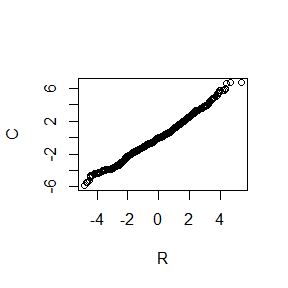

```r
library(Rcpp)
library(microbenchmark)
#C
dir_cpp='../src/'
sourceCpp(paste0(dir_cpp,"CMetro.cpp"))
#R
#standard Laplace dendity distribution
f=function(x) 0.5*exp(-abs(x))
#random walk
Metro=function(sd,x0,N){
  x=numeric(N)
  x[1]=x0
  u=runif(N)
  for (i in 2:N) {
    y=rnorm(1,x[i-1],sd)
    if(u[i]<=(f(y)/f(x[i-1]))) x[i]=y
    else {
      x[i]=x[i-1]
    }
  }
  return(x)
}
x0=10
N=3000
sd=1
R=Metro(sd,x0,N)[-(1:500)]
C=CMetro(sd,x0,N)[-(1:500)]
qqplot(R,C)
```

2.Time

```r
x0=10
N=3000
sd=1
(time=microbenchmark(R=Metro(sd,x0,N),C=CMetro(sd,x0,N)))
```

```
## Unit: microseconds
##  expr    min      lq      mean  median      uq      max neval
##     R 7687.6 8172.85 10160.146 8502.05 8959.05 107888.7   100
##     C  506.6  523.55   587.097  536.50  561.90   3894.1   100
```

Comments Their results are quite similar. But cpp codes takes significantly less time and improves the efficiency quite a lot.